# Education Freedoms

Elizabeth Swanson

2025-10-30

# Clutering Countries by Educational Freedom in 2022

## Summary

This visualization of educational freedom data is represented by a heatmap that compares education policy indicators across multiple countries for the year 2022.

1. **Cleaning:** Extracts 2022 data with valid responses from the dataset. Drops countries with missing data to ensure fair comparison
2. **Restructuring:** Converts text responses into a numeric scoring system (0 = No, 0.5 = Partial, 1 = Yes)
3. **Visualizes Patterns:** Creates a color-coded heatmap where each cell represents a country’s status on a specific education freedom question

## Insights

**Partial implementations:** The yellow color highlights nuanced situations where policies exist but with limitations, showing that education freedom isn’t always binary.

**Access the original data set here:** https://www.unesco.org/heratlas

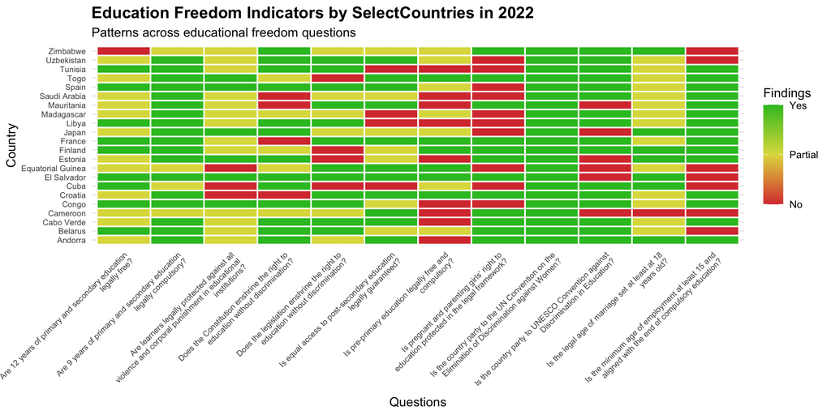

```r
edu_heatmap <- edu_data %>%
  filter(Date == 2022) %>%
  select(Country_Title, Terms, Indicator) %>%
  filter(Indicator != "") %>%
  pivot_wider(id_cols = Country_Title,
              names_from = Terms,
              values_from = Indicator) %>%
  mutate(across(-Country_Title, ~case_when(
    str_detect(., "^Yes") ~ 1,
    str_detect(., "Partially") |
      str_detect(., "Corporal punishment is allowed") |
      str_detect(., "It is discriminatory") ~ 0.5,
    str_detect(., "^No") ~ 0,
  ))) %>%
  drop_na()

edu_heatmap %>%
  pivot_longer(-Country_Title, names_to = "Indicator", values_to = "Score") %>%
  ggplot(aes(x = Indicator, y = Country_Title, fill = Score)) +
  geom_tile(color = "white", size = 0.6) +
  scale_fill_gradient2(low = "#d83c3c", mid = "#dddb4b", high = "#2dbf28",
                       midpoint = 0.5,
                       limits = c(0, 1),
                       breaks = c(0, 0.5, 1),
                       labels = c("No", "Partial", "Yes")) +
scale_x_discrete(labels = function(x) str_wrap(x, width = 50)) +
  theme_minimal() +
  labs(title = "Education Freedom Indicators by Select Countries in 2022",
       subtitle = "Patterns across educational freedom questions",
       x = "Questions",
       y = "Country",
       fill = "Findings") +
theme(axis.text.x = element_text(angle = 45, hjust = 1, size = 7),
      axis.text.y = element_text(size = 7),
      plot.title = element_text(face = "bold", size = 14))
```